# Data science project - Descriptive analysis

Yingtong Guo

```r
#import the dataset
all <- read.csv("all.csv")
```

## Frequency of topics across time

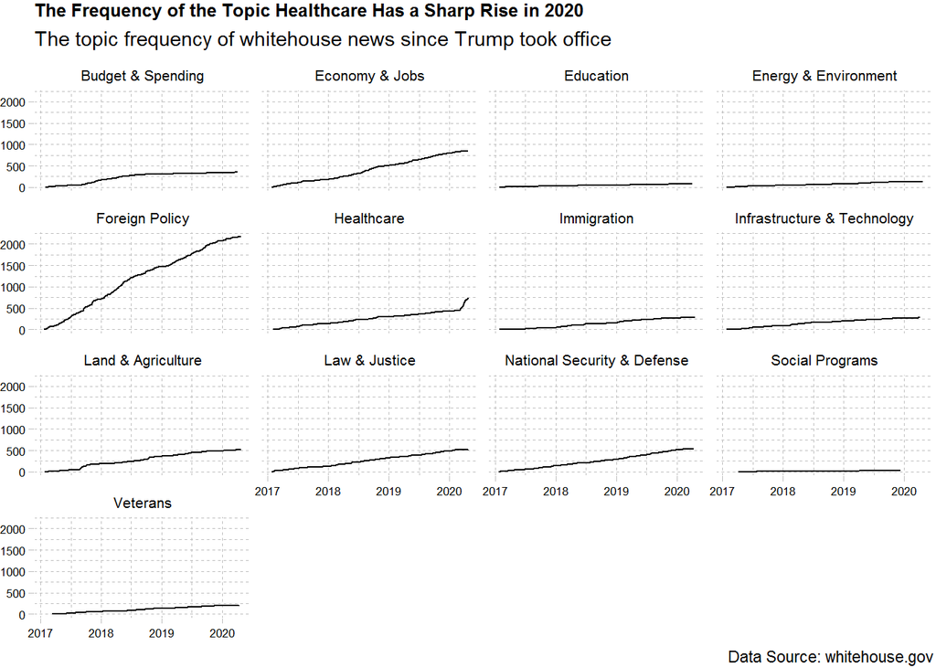

```r
#visualize the topic frequency across time
ggplot(na.omit(all), aes(x = ymd(time), y = count)) +
  geom_line() +
  xlab(NULL) +
  ylab(NULL) +
  facet_wrap(~topic) +
  theme_pander(base_size = 8, base_family = "sans") +
  labs(title = "The Frequency of the Topic Healthcare Has a Sharp Rise in 2020",
       subtitle = "The topic frequency of whitehouse news since Trump took office",
       caption = "Data Source: whitehouse.gov")
```

“Foreign Policy” is the most important topic, while “Social Programs” is the least. The frequency of most topics has a stable trend of increasing, but the frequency of “Healthcare” has a sharp rise in 2020, which is related to the coronavirus.

## Word cloud

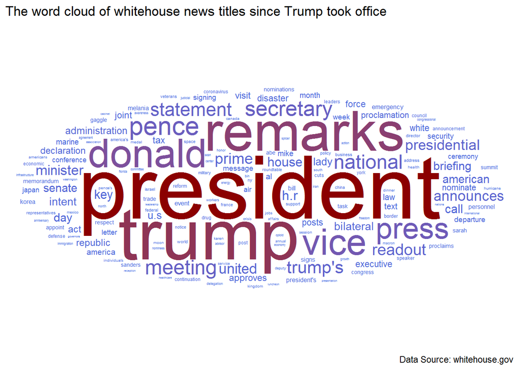

```r
#visualize the word frequency through a word cloud
#from factor to character
all$title<-as.character(all$title)

text <-
  all %>%
  group_by(id) %>%
  #from sentences to words
  unnest_tokens(word, title) %>%
  #drop stopwords
  anti_join(stop_words) %>%
  ungroup() %>%
  #drop digits
  filter(!str_detect(word, "\\d"))

wordcloud <-
  text %>%
  #count the number of times each word appears
  count(word,sort = T) %>%
  #filter out words with low frequency
  filter(n > 50)

#produce a word cloud
ggplot(wordcloud, aes(label = word, size = n, color = n)) +
  ggwordcloud::geom_text_wordcloud_area(rm_outside = TRUE) +
  scale_size_area(max_size = 30) +
  scale_color_gradient(low = "royalblue", high = "darkred") +
  theme_minimal() +
  labs(title = "The word cloud of whitehouse news titles since Trump took office",
       caption = "Data Source: whitehouse.gov")
```

I use the package `tidytext` to produce unigrams and then use the package `ggwordcloud` to produce the word cloud. The word cloud shows the most frequent words in the titles of white house news. From the graph we can see “remarks”, “trump”, “donald”, “vice”, and “president” are the top 5 most frequent words, but this graph does not give much information about the working focus of the white house. The most frequent word is “president” because all the news of remarks has a beginning of “Remarks by President Trump” or “Remarks by Vice President Pence”

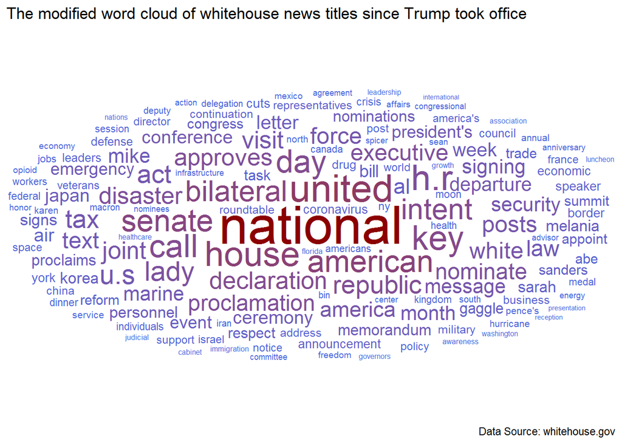

```r
#customize stopwords
mystopwords <- tibble(word = c("donald", "trump", "president", "pence", "vice", "remarks", "press", "presidential", "statement", "secretary", "meeting", "readout", "announces", "briefing", "administration", "trump's", "prime", "minister"))

wordcloud2 <-
  text %>%
  #drop the frequent words with low importance
  anti_join(mystopwords) %>%
  #count the number of times each word appears
  count(word, sort = T) %>%
  #filter out words with low frequency
  filter(n > 50)

#produce a word cloud
ggplot(wordcloud2, aes(label = word, size = n, color = n)) +
  ggwordcloud::geom_text_wordcloud_area(rm_outside = TRUE) +
  scale_size_area(max_size = 15) +
  scale_color_gradient(low = "royalblue", high = "darkred") +
  theme_minimal() +
  labs(title = "The modified word cloud of whitehouse news titles since Trump took office",
       caption = "Data Source: whitehouse.gov")
```

## Reference

1. Pennec, E., & Slowikowski, K. (2018). ggwordcloud: A Word Cloud Geom for’ggplot2’. R package version 0.3. 0. URL https://cran.r-project.org/package=ggwordcloud.